# Volatility & Macro Correlation (R) — Full Walkthrough (with Regimes & Backtest)

## 1 1. Objective

### 1.1 What is this project?

We study the interaction between:

- **Equity volatility proxies** (1M and 1Y volatility measures)
- **Macro variables** (inflation, GDP growth, unemployment, policy rate)
- **Forward equity returns** (a simple “next period” return, provided in the dataset)

We use **two instructor-provided datasets**:

- `data_full`: broad panel (many stocks over time) with `Vol_1M` and basic fundamentals.
- `spx_macro`: panel enriched with macro variables and `fwd_return`.

### 1.2 Why do we do it?

If volatility is linked to macro conditions, we can:

1. describe **volatility cycles** (time-series)
2. identify **macro/volatility regimes**
3. test whether a **simple hedge/tilt** performs differently across regimes

> Important note about “Volatility Smile”  
> A *true* implied-volatility smile needs option chains (strike/maturity/call-put).  
> Here we **do not** have option chains; we therefore work with **volatility proxies** (`vol_1m`, `vol_1y`) and macro data.

## 2 2. Setup

### 2.1 What is this block?

We load packages, create output folders, and load the `.RData` files.

### 2.2 Why do we do it?

- Packages provide the main data and plotting tools.
- Output folders make the project reproducible (figures/tables saved to disk).
- Loading `.RData` gives access to the instructor datasets.

```r
# -------------------------------
# 2.1 Packages (install if needed)
# -------------------------------

# List packages we will use (minimal and common)
pkgs <- c(
  "tidyverse",  # dplyr + ggplot2 + readr + etc. + %>%
  "lubridate",  # date helpers
  "zoo",        # rolling windows
  "broom"       # tidy regression outputs
)

# Install any missing packages (run once on a new machine)
missing_pkgs <- pkgs[!pkgs %in% rownames(installed.packages())]  # check installed packages
if (length(missing_pkgs) > 0) {                                  # if some are missing
  install.packages(missing_pkgs)                                  # install them
}

# Load packages into the session
library(tidyverse)   # loads dplyr/ggplot2/readr/purrr/tibble + pipe operator %>%
library(lubridate)   # date parsing and helpers
library(zoo)         # rollapply for rolling correlations
library(broom)       # tidy() for regression outputs

# --------------------------------
# 2.2 Project output directories
# --------------------------------

dir.create("output", showWarnings = FALSE, recursive = TRUE)          # main output directory
dir.create("output/figures", showWarnings = FALSE, recursive = TRUE)  # saved plots
dir.create("output/tables", showWarnings = FALSE, recursive = TRUE)   # saved tables

# -------------------------------
# 2.3 Load the instructor datasets
# -------------------------------

load("data/raw/data_full.RData")   # loads object: data_full (expected)
load("data/raw/spx_macro.RData")   # loads object: spx_macro (expected)

# -------------------------------
# 2.4 Quick sanity checks
# -------------------------------

stopifnot(exists("data_full"))     # stop if object doesn't exist
stopifnot(exists("spx_macro"))     # stop if object doesn't exist

glimpse(data_full)                 # inspect columns/types quickly
```

```
Rows: 291,392
Columns: 7
$ Tick    <chr> "AA", "AA", "AA", "AA", "AA", "AA", "AA", "AA", "AA", "AA", "A…
$ Date    <date> 1995-01-31, 1995-02-28, 1995-03-31, 1995-04-28, 1995-05-31, 1…
$ Close   <dbl> 15.1625, 15.0420, 16.0062, 17.3079, 18.0250, 19.4302, 22.0952,…
$ Vol_1M  <dbl> 26.668, 34.814, 38.133, 38.243, 37.438, 24.164, 27.889, 26.036…
$ Mkt_Cap <dbl> 7025.616, 3484.884, 7393.308, 7994.571, 8284.068, 8947.062, 10…
$ P2B     <dbl> 0.9162, 0.9089, 0.9463, 1.0233, 1.0657, 1.0985, 1.2492, 1.2570…
$ D2E     <dbl> 25.4211, 25.4211, 25.1125, 25.1125, 25.1125, 25.1214, 25.1214,…
```

```r
glimpse(spx_macro)                 # inspect columns/types quickly
```

```
Rows: 159,899
Columns: 31
$ symbol         <chr> "A", "A", "A", "A", "A", "A", "A", "A", "A", "A", "A", …
$ name           <chr> "Agilent Technologies Inc", "Agilent Technologies Inc",…
$ sector         <chr> "Manufacturing", "Manufacturing", "Manufacturing", "Man…
$ date           <dttm> 2000-11-30, 2000-12-31, 2001-01-31, 2001-02-28, 2001-0…
$ close          <dbl> 35.162409, 36.888946, 36.754192, 24.255745, 20.704974, …
$ vol_1y         <dbl> 1.2830374, 0.9794414, 0.9659139, 0.8185208, 0.8201086, …
$ volume         <dbl> 2797300, 0, 1366900, 2145000, 0, 1023100, 2943000, 0, 1…
$ mkt_cap        <dbl> 14135869641, 14135869641, 14135869641, 14135869641, 141…
$ revenue        <dbl> 9.361e+09, 9.361e+09, 9.361e+09, 9.361e+09, 9.361e+09, …
$ dy             <dbl> 0, 0, 0, 0, 0, 0, 0, 0, 0, 0, 0, 0, 0, 0, 0, 0, 0, 0, 0…
$ ebit           <dbl> NA, NA, NA, NA, NA, NA, NA, NA, NA, NA, NA, NA, NA, NA,…
$ profit_margin  <dbl> 51.00951, 51.00951, 51.00951, 51.00951, 51.00951, 51.00…
$ p2b            <dbl> 2.6905966, 2.6905966, 2.6905966, 2.6905966, 2.6905966, …
```

[output cut: 18 more lines]

### 2.3 Key observation (from `glimpse()`)

- `data_full` contains `Tick`, `Date`, `Close`, `Vol_1M` (and fundamentals).
- `spx_macro` contains `symbol`, `sector`, `date`, `vol_1y`, `fwd_return` and macro variables.

### 2.4 Limitations

- Variable names differ in capitalization (`Vol_1M` vs `vol_1y`). We standardize them next.

## 3 3. Standardize columns and build “clean” datasets

### 3.1 What is this block?

We rename columns to lowercase to avoid case issues, and keep only columns we need.

### 3.2 Why do we do it?

- Lowercase column names reduce mistakes (`Date` vs `date`).
- Creating “analysis tables” makes downstream steps simpler and reproducible.

```r
# -----------------------------------------
# 3.1 Standardize column names to lowercase
# -----------------------------------------

df1 <- data_full %>% rename_with(tolower)  # make all names lowercase (data_full)
df2 <- spx_macro %>% rename_with(tolower)  # make all names lowercase (spx_macro)

# -------------------------------------------------------
# 3.2 Build a clean volatility panel from data_full (df1)
# -------------------------------------------------------

# Keep only the essentials: identifier, date, close, 1M volatility
vol_panel <- df1 %>%
  mutate(date = as.Date(date)) %>%         # ensure Date type
  transmute(
    tick   = tick,                         # stock identifier
    date   = date,                         # date
    close  = close,                        # close price
    vol_1m = vol_1m                        # 1M volatility proxy
  ) %>%
  filter(!is.na(date)) %>%                 # remove rows with missing date
  filter(!is.na(vol_1m))                   # keep rows where vol is available

# -------------------------------------------------------
# 3.3 Build a clean macro panel from spx_macro (df2)
# -------------------------------------------------------

macro_panel <- df2 %>%
  mutate(date = as.Date(date)) %>%         # ensure Date type
  transmute(
    symbol       = symbol,                 # stock identifier
    sector       = sector,                 # sector label
    date         = date,                   # date
    close        = close,                  # close price
    vol_1y       = vol_1y,                 # 1Y volatility proxy
    ret          = `return`,               # realized return (current period)
    fwd_return   = fwd_return,             # forward return (next period)
    inflation    = inflation,              # macro: inflation
    gdp_growth   = gdp_growth,             # macro: GDP growth
    unemployment = unemployment,           # macro: unemployment
    fed_rate     = fed_rate                # macro: policy rate
  ) %>%
  filter(!is.na(date)) %>%                 # remove missing date
  filter(!is.na(fwd_return))               # forward return is required later
```

### 3.3 Key observation

- We now have two consistent tables: `vol_panel` and `macro_panel`.

### 3.4 Limitations

- Any row with missing `fwd_return` is removed, which can reduce sample size.
- Macro variables may contain NAs; we handle them later (e.g., correlations/regressions need complete pairs).

## 4 4. Volatility distribution (cross-sectional)

### 4.1 What is this block?

We visualize the distribution of 1M volatility across all stocks/dates.

### 4.2 Why do we do it?

Volatility distributions often have: - strong right tails (rare extreme values) - outliers that make a standard histogram unreadable

So we plot: 1) **raw distribution** (may be dominated by outliers) 2) **trimmed distribution** (better readability; outliers removed from *plot only*)

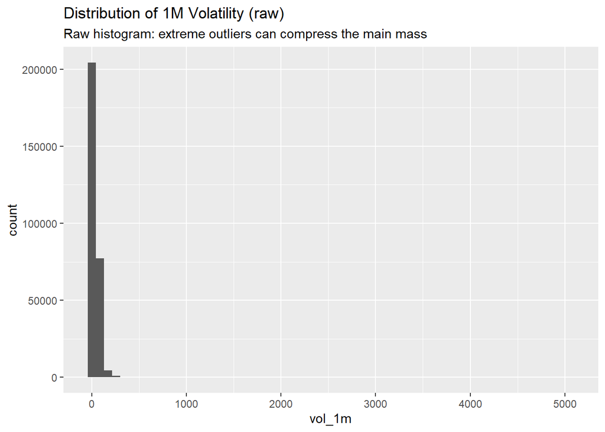

```r
# ---------------------------------------------------------
# 4.1 Raw histogram (may be distorted by extreme outliers)
# ---------------------------------------------------------

p_hist_raw <- vol_panel %>%
  ggplot(aes(x = vol_1m)) +                         # map vol_1m to x-axis
  geom_histogram(bins = 60) +                       # histogram with 60 bins
  labs(
    title = "Distribution of 1M Volatility (raw)",
    subtitle = "Raw histogram: extreme outliers can compress the main mass",
    x = "vol_1m",
    y = "count"
  )

p_hist_raw
```

### 4.3 Key observation

If the histogram looks “flat” with most bars near zero, it usually means **a few huge outliers** stretch the x-axis.

### 4.4 Interpretation

- Volatility is **right-skewed**: most observations are in a moderate range, with rare very high values.

### 4.5 Limitations

- A raw histogram can hide the main distribution because of outliers.

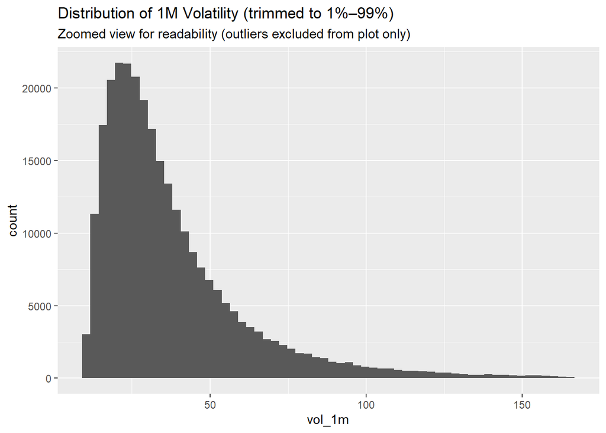

```r
# ---------------------------------------------------------
# 4.2 Trimmed histogram (improved readability)
#     NOTE: outliers excluded from plot ONLY (not from data)
# ---------------------------------------------------------

# Compute 1% and 99% quantiles for plotting range
q <- quantile(vol_panel$vol_1m, probs = c(0.01, 0.99), na.rm = TRUE)  # quantiles

p_hist_trim <- vol_panel %>%
  filter(vol_1m >= q[1], vol_1m <= q[2]) %>%        # keep middle 98% for plotting
  ggplot(aes(x = vol_1m)) +                         # map vol_1m to x-axis
  geom_histogram(bins = 60) +                       # histogram with 60 bins
  labs(
    title = "Distribution of 1M Volatility (trimmed to 1%–99%)",
    subtitle = "Zoomed view for readability (outliers excluded from plot only)",
    x = "vol_1m",
    y = "count"
  )

p_hist_trim
```

### 4.6 Key observation

Now the bulk shape becomes visible (peak + long tail).

### 4.7 Interpretation

- Many observations cluster around a “typical” vol range.
- Tail risk exists: a smaller set of observations has much higher volatility.

### 4.8 Limitations

- Trimming is purely visual; it can mislead if the reader forgets that outliers exist.

## 5 5. Market-wide volatility proxy over time

### 5.2 Why do we do it?

A market-wide volatility proxy helps us: - detect volatility regimes (calm vs crisis) - compare with macro variables later

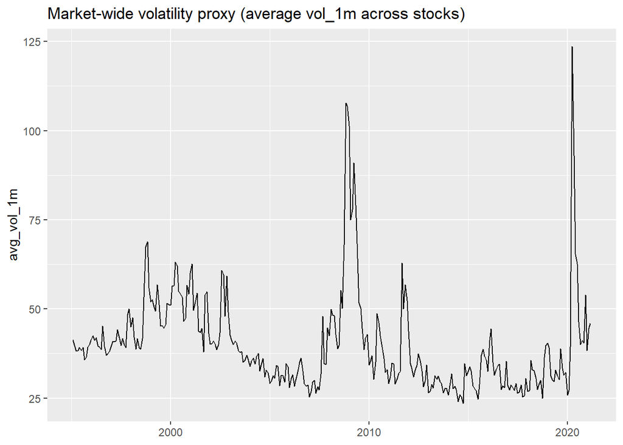

```r
# ---------------------------------------------------------
# 5.1 Build the market volatility proxy (average vol_1m)
# ---------------------------------------------------------

vol_ts <- vol_panel %>%
  group_by(date) %>%                               # group by date
  summarise(
    avg_vol_1m = mean(vol_1m, na.rm = TRUE),        # cross-sectional average volatility
    n          = n(),                               # number of observations that day
    .groups    = "drop"                             # return a normal tibble
  ) %>%
  arrange(date)                                    # sort by date

# ---------------------------------------------------------
# 5.2 Plot the market volatility proxy
# ---------------------------------------------------------

p_vol_ts <- vol_ts %>%
  ggplot(aes(x = date, y = avg_vol_1m)) +           # date on x, avg vol on y
  geom_line() +                                     # line plot
  labs(
    title = "Market-wide volatility proxy (average vol_1m across stocks)",
    x = NULL,
    y = "avg_vol_1m"
  )

p_vol_ts
```

### 5.3 Key observation

You should see spikes during crisis periods (e.g., 2008–2009, 2020).

### 5.4 Interpretation

- Volatility clusters: calm periods followed by high-volatility bursts.
- These bursts often coincide with macro stress.

### 5.5 Limitations

- Equal-weight averaging gives the same weight to small and large firms.
- Alternative: value-weighted average using market cap (not done here).

## 6 6. Macro variables: a clean monthly macro time series

### 6.1 What is this block?

We build a **macro time series** (one row per date) by taking the first available macro values per date.

### 6.2 Why do we do it?

Macro variables are repeated across many stocks on the same date in `spx_macro`. For correlation analysis, we want **one macro row per date**.

```r
# ---------------------------------------------------------
# 6.1 Extract a macro-only time series (one row per date)
# ---------------------------------------------------------

macro_ts <- macro_panel %>%
  group_by(date) %>%                               # group by date
  summarise(
    inflation    = first(na.omit(inflation)),       # take first non-NA inflation
    gdp_growth   = first(na.omit(gdp_growth)),      # take first non-NA GDP growth
    unemployment = first(na.omit(unemployment)),    # take first non-NA unemployment
    fed_rate     = first(na.omit(fed_rate)),        # take first non-NA policy rate
    .groups      = "drop"                           # return a normal tibble
  ) %>%
  arrange(date)                                    # sort by date

# ---------------------------------------------------------
# 6.2 Basic summary statistics (sanity check)
# ---------------------------------------------------------

summary(macro_ts)                                   # quick descriptive stats
```

```
      date              inflation         gdp_growth        unemployment
 Min.   :1991-01-31   Min.   :-0.8000   Min.   :-31.4000   Min.   : 3.533
 1st Qu.:1999-09-15   1st Qu.: 0.0000   1st Qu.:  0.0000   1st Qu.: 4.333
 Median :2008-04-30   Median : 0.0000   Median :  0.0000   Median : 5.333
 Mean   :2008-04-30   Mean   : 0.0747   Mean   :  0.8492   Mean   : 5.698
 3rd Qu.:2016-12-15   3rd Qu.: 0.1000   3rd Qu.:  1.4000   3rd Qu.: 6.667
 Max.   :2025-07-31   Max.   : 1.4000   Max.   : 33.4000   Max.   :13.000
                                                           NA's   :2
    fed_rate
 Min.   :0.125
 1st Qu.:0.125
 Median :2.375
 Mean   :2.714
 3rd Qu.:5.125
 Max.   :6.500
 NA's   :2
```

### 6.3 Key observation

- Some macro series can contain NAs for early dates.
- Ranges may look unusual if values are in “percent points” or scaled units (depends on instructor data).

### 6.4 Limitations

- Using `first(na.omit(x))` assumes macro is constant across stocks within each date.
- If macro differs across stocks (should not happen), this would hide that inconsistency.

## 7 7. Rolling correlation: macro vs market volatility

### 7.1 What is this block?

We compute **rolling correlations** between each macro variable and the market volatility proxy.

### 7.2 Why do we do it?

Correlations are not stable over time. Rolling correlations reveal: - regime changes - periods where macro-vol links strengthen/weaken

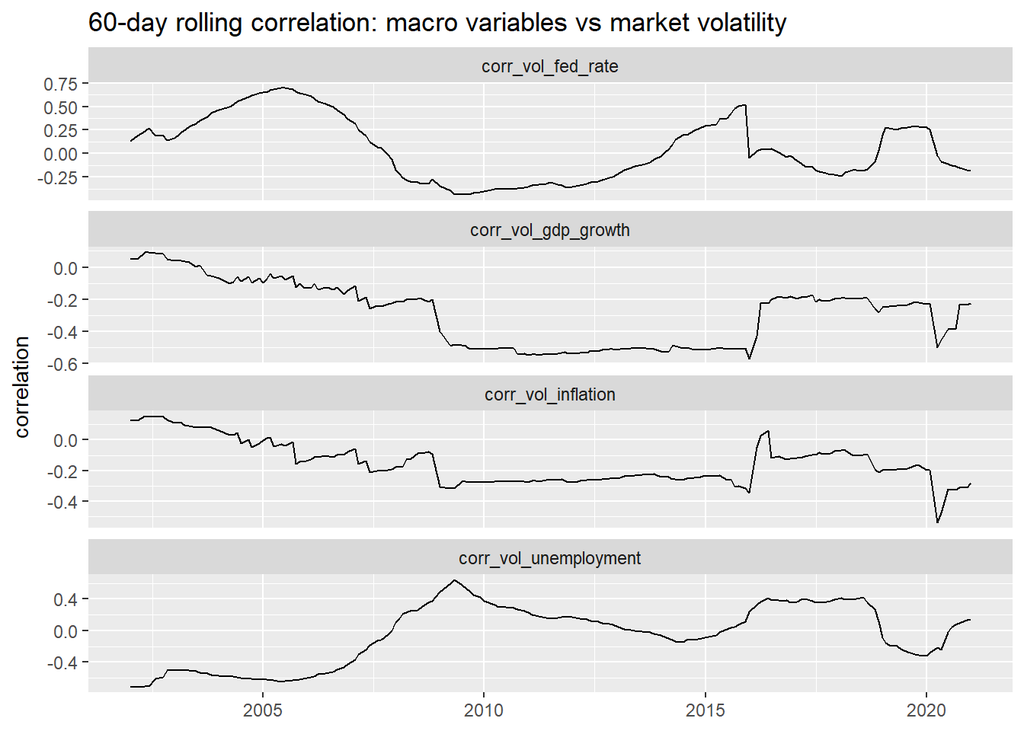

```r
# ---------------------------------------------------------
# 7.1 Merge macro time series with market volatility
# ---------------------------------------------------------

macro_vol <- vol_ts %>%
  inner_join(macro_ts, by = "date") %>%            # keep dates common to both
  arrange(date)                                    # sort by date

# ---------------------------------------------------------
# 7.2 Rolling correlation function
# ---------------------------------------------------------

roll_corr <- function(x, y, width = 60) {           # define a helper function
  zoo::rollapply(                                   # apply over rolling windows
    data = cbind(x, y),                              # combine as a 2-col matrix
    width = width,                                   # window length
    FUN = function(m) cor(m[, 1], m[, 2], use = "complete.obs"), # correlation
    by.column = FALSE,                               # treat matrix as one object
    align = "right",                                 # right-aligned (uses past)
    fill = NA                                        # pad beginning with NA
  )
}

# ---------------------------------------------------------
# 7.3 Compute rolling correlations for each macro variable
# ---------------------------------------------------------

macro_vol <- macro_vol %>%
  mutate(
    corr_vol_inflation    = roll_corr(avg_vol_1m, inflation,    width = 60),
    corr_vol_gdp_growth   = roll_corr(avg_vol_1m, gdp_growth,   width = 60),
    corr_vol_unemployment = roll_corr(avg_vol_1m, unemployment, width = 60),
    corr_vol_fed_rate     = roll_corr(avg_vol_1m, fed_rate,     width = 60)
  )

# ---------------------------------------------------------
# 7.4 Plot rolling correlations (facet plot)
# ---------------------------------------------------------

corr_long <- macro_vol %>%
  select(date, starts_with("corr_vol_")) %>%        # keep date + corr columns
  pivot_longer(
    cols = starts_with("corr_vol_"),                # pivot correlation columns
    names_to = "series",                            # name column
    values_to = "corr"                              # value column
  ) %>%
  filter(!is.na(corr))                              # drop leading NA windows

p_roll_corr <- corr_long %>%
  ggplot(aes(x = date, y = corr)) +                 # date vs correlation
  geom_line() +                                     # line
  facet_wrap(~ series, ncol = 1, scales = "free_y") + # one panel per series
  labs(
    title = "60-day rolling correlation: macro variables vs market volatility",
    x = NULL,
    y = "correlation"
  )

p_roll_corr
```

### 7.3 Key observation

Correlations vary over time; you may see sign changes.

### 7.4 Interpretation

- If the correlation becomes strongly positive/negative during crises, it suggests macro stress is tightly linked to volatility then.
- Different macro variables can matter in different periods.

## 8 8. Regime detection (k-means clustering)

### 8.1 What is this block?

We define simple “regimes” by clustering on: - market volatility (`avg_vol_1m`) - macro variables (inflation, GDP growth, unemployment, fed rate)

### 8.2 Why do we do it?

Regimes simplify analysis: - “high vol + weak growth” vs “low vol + normal growth” - later we can compare strategy performance across regimes

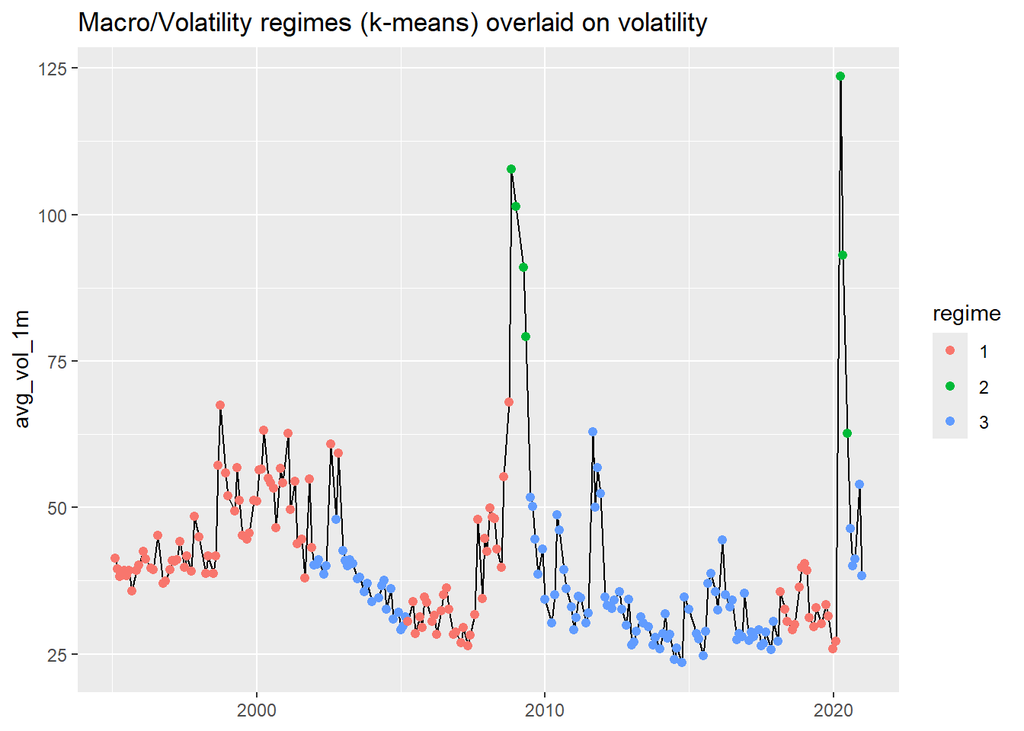

```r
# ---------------------------------------------------------
# 8.1 Prepare features for clustering
# ---------------------------------------------------------

regime_df <- macro_vol %>%
  select(date, avg_vol_1m, inflation, gdp_growth, unemployment, fed_rate) %>% # select features
  drop_na()                                          # k-means needs complete cases

# Standardize features (important for k-means)
X <- regime_df %>%
  select(-date) %>%                                  # remove date
  scale()                                            # standardize to mean 0, sd 1

# ---------------------------------------------------------
# 8.2 Run k-means (k = 3)
# ---------------------------------------------------------

set.seed(42)                                         # for reproducibility
km <- kmeans(X, centers = 3, nstart = 25)             # k-means clustering

regime_df <- regime_df %>%
  mutate(regime = factor(km$cluster))                 # attach cluster labels

# ---------------------------------------------------------
# 8.3 Plot regimes on top of volatility
# ---------------------------------------------------------

p_regime <- regime_df %>%
  ggplot(aes(x = date, y = avg_vol_1m)) +             # date vs volatility
  geom_line() +                                       # volatility line
  geom_point(aes(color = regime), size = 1.8) +       # regime points
  labs(
    title = "Macro/Volatility regimes (k-means) overlaid on volatility",
    x = NULL,
    y = "avg_vol_1m",
    color = "regime"
  )

p_regime
```

### 8.3 Key observation

One regime will typically map to “spike” periods (high volatility).

### 8.4 Interpretation

- Regimes are data-driven clusters: they represent typical combinations of macro + vol.
- A regime with **high avg volatility** often corresponds to recessions/stress.

### 8.5 Limitations

- k-means assumes spherical clusters and depends on scaling.
- `k=3` is arbitrary; other k values may fit better.

```r
# ---------------------------------------------------------
# 8.4 Summarize regimes (mean macro/vol by cluster)
# ---------------------------------------------------------

regime_summary <- regime_df %>%
  group_by(regime) %>%                               # group by regime
  summarise(
    avg_vol           = mean(avg_vol_1m, na.rm = TRUE),        # mean volatility
    mean_inflation    = mean(inflation, na.rm = TRUE),         # mean inflation
    mean_gdp_growth   = mean(gdp_growth, na.rm = TRUE),        # mean GDP growth
    mean_unemployment = mean(unemployment, na.rm = TRUE),      # mean unemployment
    mean_fed_rate     = mean(fed_rate, na.rm = TRUE),          # mean fed rate
    n                 = n(),                                   # count observations
    .groups           = "drop"                                 # return tibble
  ) %>%
  arrange(regime)                                    # sort by regime id

regime_summary                                       # print table
```

```
# A tibble: 3 × 7
  regime avg_vol mean_inflation mean_gdp_growth mean_unemployment mean_fed_rate
  <fct>    <dbl>          <dbl>           <dbl>             <dbl>         <dbl>
1 1         41.6         0.0782           0.966              4.66         4.44
2 2         94.1        -0.129           -6.89               7.15         0.393
3 3         35.0         0.0642           1.25               6.92         0.552
# ℹ 1 more variable: n <int>
```

```r
write_csv(regime_summary, "output/tables/regime_summary.csv")  # save to CSV
```

### 8.6 Key observation

You can label regimes qualitatively based on the averages (e.g., “high vol / weak growth”).

### 8.7 Limitations

- These are *sample averages*; regime interpretation may be unstable if sample changes.

## 9 9. Baseline regression: what drives forward returns?

### 9.2 Why do we do it?

This is a basic “sanity check” to see: - which variables correlate with forward returns (in-sample) - the *direction* of association

```r
# ---------------------------------------------------------
# 9.1 Build the regression dataset (complete cases)
# ---------------------------------------------------------

model_df <- macro_panel %>%
  select(
    fwd_return,                                      # dependent variable
    vol_1y,                                          # volatility proxy
    inflation, gdp_growth, unemployment, fed_rate     # macro features
  ) %>%
  drop_na()                                          # keep complete rows only

summary(model_df$fwd_return)                          # quick check of forward returns distribution
```

```
     Min.   1st Qu.    Median      Mean   3rd Qu.      Max.
-0.845044 -0.035298  0.008834  0.013153  0.058490 26.000000
```

```r
# ---------------------------------------------------------
# 9.2 Fit the pooled regression model
# ---------------------------------------------------------

reg_fit <- lm(
  fwd_return ~ vol_1y + inflation + gdp_growth + unemployment + fed_rate,  # formula
  data = model_df                                                         # dataset
)

print(summary(reg_fit))                             # print regression results (explicit)
```

```
Call:
lm(formula = fwd_return ~ vol_1y + inflation + gdp_growth + unemployment +
    fed_rate, data = model_df)

Residuals:
    Min      1Q  Median      3Q     Max
-0.8570 -0.0481 -0.0036  0.0458 25.9751

Coefficients:
               Estimate Std. Error t value Pr(>|t|)
(Intercept)  -0.0117417  0.0013690  -8.577  < 2e-16 ***
vol_1y        0.0143461  0.0010272  13.967  < 2e-16 ***
inflation     0.0118316  0.0015208   7.780 7.31e-15 ***
gdp_growth   -0.0003796  0.0001000  -3.794 0.000148 ***
unemployment  0.0030661  0.0001893  16.196  < 2e-16 ***
fed_rate      0.0011412  0.0001598   7.142 9.24e-13 ***
---
Signif. codes:  0 '***' 0.001 '**' 0.01 '*' 0.05 '.' 0.1 ' ' 1

Residual standard error: 0.1176 on 158555 degrees of freedom
Multiple R-squared:  0.003559,  Adjusted R-squared:  0.003527
F-statistic: 113.3 on 5 and 158555 DF,  p-value: < 2.2e-16
```

```r
# ---------------------------------------------------------
# 9.3 Tidy coefficients for easier reporting
# ---------------------------------------------------------

coef_tbl <- broom::tidy(reg_fit) %>%                # tidy regression output
  arrange(p.value)                                  # sort by p-value (most significant first)

coef_tbl                                             # print coefficient table
```

```
# A tibble: 6 × 5
  term          estimate std.error statistic  p.value
  <chr>            <dbl>     <dbl>     <dbl>    <dbl>
1 unemployment  0.00307   0.000189     16.2  5.99e-59
2 vol_1y        0.0143    0.00103      14.0  2.65e-44
3 (Intercept)  -0.0117    0.00137      -8.58 9.82e-18
4 inflation     0.0118    0.00152       7.78 7.31e-15
5 fed_rate      0.00114   0.000160      7.14 9.24e-13
6 gdp_growth   -0.000380  0.000100     -3.79 1.48e- 4
```

```r
write_csv(coef_tbl, "output/tables/regression_coefficients.csv")  # save to CSV
```

### 9.3 Key observations (how to read the output)

- **Sign** of each coefficient: direction of association with `fwd_return`.
- **p-value**: statistical significance (in-sample).
- **R²**: explanatory power.

### 9.4 Interpretation (what your output suggests)

In your results (as shown in the HTML output):

- `vol_1y`, `inflation`, `unemployment`, `fed_rate` show **positive** coefficients.
- `gdp_growth` shows a **negative** coefficient (small magnitude).
- The **R² is very low** (~0.003–0.004): macro + vol explain only a tiny fraction of cross-sectional forward returns.

This is common in equity panels: forward returns are noisy and hard to explain with a few macro variables.

### 9.5 Limitations

- Pooled OLS ignores fixed effects (stock/sector/time).
- Macros are mostly time-series, while returns are stock-level → strong residual noise.
- Statistical significance can be driven by huge sample size.

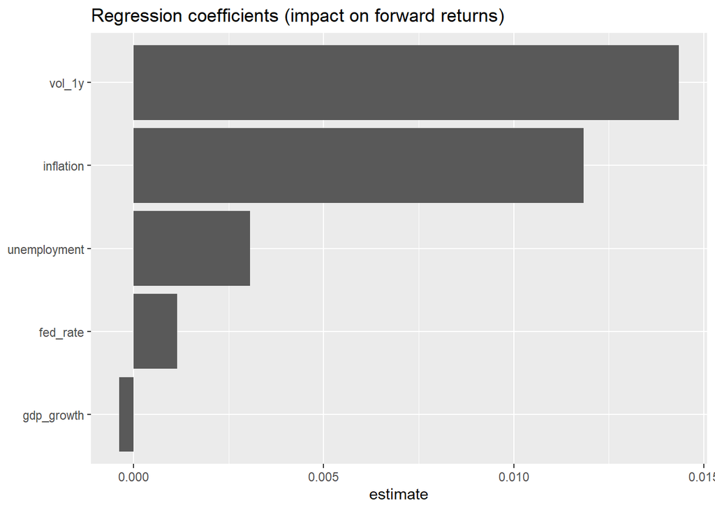

```r
# ---------------------------------------------------------
# 9.4 Plot regression coefficient estimates (excluding intercept)
# ---------------------------------------------------------

p_coef <- coef_tbl %>%
  filter(term != "(Intercept)") %>%                  # remove intercept for plot clarity
  ggplot(aes(x = reorder(term, estimate), y = estimate)) +  # order bars by estimate
  geom_col() +                                       # bar chart
  coord_flip() +                                     # horizontal bars
  labs(
    title = "Regression coefficients (impact on forward returns)",
    x = NULL,
    y = "estimate"
  )

p_coef
```

```r
ggsave("output/figures/regression_coefficients.png", p_coef, width = 9, height = 5)
```

### 9.6 Key observation

This plot is a visual ranking of coefficients (not necessarily “importance”).

### 9.7 Limitation

Coefficients are in different units (inflation points vs rate points), so comparing magnitudes can be misleading.

## 10 10. Backtest: simple low-vol vs high-vol strategy

### 10.1 What is this block?

We test a simple **cross-sectional strategy** at each rebalancing date:

1. Sort stocks by `vol_1y` (risk proxy / volatility level)
2. Build portfolios equal-weight portfolios:
   - **Low-vol**: bottom 20%
   - **High-vol**: top 20%
3. Use `fwd_return` as the *next-period* realized return for each stock
4. Compute:
   - long-only Low-vol
   - long-only High-vol
   - **Long-Short (Low − High)**

### 10.2 Why do we do it?

To check if: - To check whether a classic “low-volatility effect” is present in the dataset (i.e., low-vol outperforming high-vol). - To understand how performance behaves across market regimes (calm vs stress). - To provide an economic complement to correlations/regressions: even if a relation exists statistically, is it meaningful in a tradable portfolio setting?

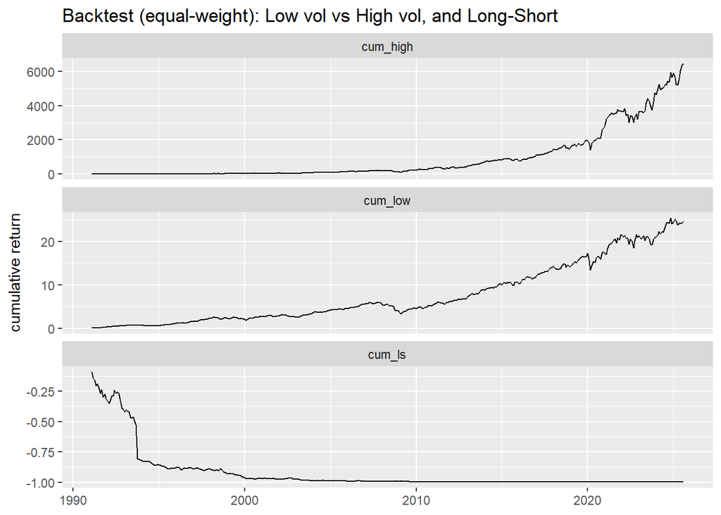

```r
# ------------------------------------------------------------
# 10.1 Prepare strategy universe (needed columns only)
# ------------------------------------------------------------

bt_universe <- macro_panel %>%                                  # start from the merged panel dataset
  select(date, symbol, vol_1y, fwd_return) %>%                  # keep only what the backtest needs
  drop_na(vol_1y, fwd_return) %>%                               # require both volatility and forward return
  arrange(date, symbol)                                         # sort for stable and reproducible results

# ------------------------------------------------------------
# 10.2 Assign vol-quantile buckets by date (bottom/top 20%)
# ------------------------------------------------------------

bt_buckets <- bt_universe %>%                                   # use the universe built in 10.1
  group_by(date) %>%                                            # form cross-sectional buckets each date
  mutate(
    q20 = quantile(vol_1y, 0.20, na.rm = TRUE),                  # compute 20th percentile of vol (low-vol cutoff)
    q80 = quantile(vol_1y, 0.80, na.rm = TRUE),                  # compute 80th percentile of vol (high-vol cutoff)
    bucket = case_when(
      vol_1y <= q20 ~ "low_vol",                                 # bottom 20% volatility names
      vol_1y >= q80 ~ "high_vol",                                # top 20% volatility names
      TRUE        ~ "mid"                                        # middle 60% (not used in long-short)
    )
  ) %>%
  ungroup()                                                     # remove date grouping

# ------------------------------------------------------------
# 10.3 Compute portfolio returns (equal-weight) by date
# ------------------------------------------------------------

bt_ports <- bt_buckets %>%                                      # start from bucketed data
  filter(bucket %in% c("low_vol", "high_vol")) %>%              # keep only the two tails (20/80)
  group_by(date, bucket) %>%                                    # compute portfolio return per date and bucket
  summarize(
    port_ret = mean(fwd_return, na.rm = TRUE),                   # equal-weight average forward return
    n_names  = n(),                                              # number of stocks in the bucket
    .groups  = "drop"                                            # drop grouping after summarize
  ) %>%
  pivot_wider(
    names_from  = bucket,                                        # create columns: low_vol, high_vol
    values_from = port_ret                                       # values are portfolio returns
  ) %>%
  mutate(
    ls_ret = low_vol - high_vol                                  # long-short return: low minus high
  ) %>%
  arrange(date)                                                 # sort by date

# ------------------------------------------------------------
# 10.4 Convert to cumulative performance (simple compounding)
# ------------------------------------------------------------

scale_check <- median(abs(bt_ports$high_vol), na.rm = TRUE)      # typical magnitude of high-vol returns

if (is.finite(scale_check) && scale_check > 0.5) {               # if returns look like percentages (e.g., 2 = 2%)
  bt_ports <- bt_ports %>%                                       # rescale everything consistently
    mutate(
      low_vol  = low_vol  / 100,                                 # convert % -> decimal
      high_vol = high_vol / 100,                                 # convert % -> decimal
      ls_ret   = ls_ret   / 100                                  # convert % -> decimal
    )
}

bt_cum <- bt_ports %>%                                           # start from rescaled returns
  mutate(
    cum_low  = cumprod(1 + low_vol)  - 1,                        # compounded cumulative return for low-vol
    cum_high = cumprod(1 + high_vol) - 1,                        # compounded cumulative return for high-vol
    cum_ls   = cumprod(1 + ls_ret)   - 1                         # compounded cumulative return for long-short
  )

# ------------------------------------------------------------
# 10.5 Plot cumulative returns
# ------------------------------------------------------------

bt_long <- bt_cum %>%                                            # start from cumulative returns dataset
  select(date, cum_low, cum_high, cum_ls) %>%                    # keep only cumulative series
  pivot_longer(
    cols = -date,                                                # pivot all cumulative columns
    names_to = "strategy",                                       # strategy label
    values_to = "cum_return"                                     # cumulative value
  )

p_bt <- ggplot(bt_long, aes(x = date, y = cum_return)) +         # map date to x, cumulative return to y
  geom_line() +                                                  # draw lines
  facet_wrap(~ strategy, ncol = 1, scales = "free_y") +          # one panel per strategy (free scale for readability)
  labs(
    title = "Backtest (equal-weight): Low vol vs High vol, and Long-Short", # title
    x = NULL,                                                    # no x label
    y = "cumulative return"                                      # y label
  )

p_bt                                                            # display plot
```

### 10.3 Key observations (how to read)

In your results: -`cum_high` dominates `cum_low` strongly. -`cum_ls` turns negative early and remains negative. This indicates high-vol outperformance in this dataset over the sample.

### 10.4 Interpretation

This backtest suggests that the dataset rewards riskier (high-volatility) stocks more than defensive low-volatility stocks, at least in the way the strategy is constructed (equal-weight tails with `vol_1y`, using `fwd_return`).

Economically, this can be consistent with: -Risk premia: investors demand higher expected returns to hold more volatile stocks. -Rebound / crash-recovery effects: high-vol names can surge during recoveries after stress periods. -Sample composition: if the universe contains many “high-beta/high-vol growth” stocks, the high-vol basket can mechanically outperform.

Most importantly: the long-short “Low − High” being negative means the classical low-vol anomaly does not dominate here (at least not under this exact definition and weighting).

### 10.5 Limitations

-This backtest is illustrative: no transaction costs no liquidity / bid-ask filters no leverage constraints equal-weight portfolios (not value-weighted) -`fwd_return` definition matters: If `fwd_return` is “next month return”, the strategy is monthly. If it is computed differently, the interpretation changes. We assume alignment is correct (date t → forward return t+1). -Outliers and scaling: Extreme returns can dominate equal-weight means. Percent vs decimal scaling must be checked (2 vs 0.02). For robustness, you may want winsorization (e.g., cap returns at 1%/99%). -Look-ahead / availability bias risk: Volatility measures must be known at time t (not using future data). Survivorship bias can inflate returns if the dataset excludes delisted names.

## 11 11. Backtest by regime (conditional performance)

### 11.1 What is this block?

We repeat the same Low-vol / High-vol / Long-Short construction, but we condition performance on the macro/volatility regimes (e.g., from k-means clustering). For each regime, we compute average returns:

-`mean_low` = average Low-vol portfolio return in that regime -`mean_high` = average High-vol portfolio return in that regime -`mean_ls` = average (Low − High) return in that regime -`n_dates` = number of dates available in that regime

### 11.2 Why do we do it?

-Because relationships can be regime-dependent: a strategy may work in calm periods but fail in stress periods (or the opposite).

-This provides a simple way to test whether the Low-vol vs High-vol spread changes across different macro environments.

```r
# ---------------------------------------------------------
# 11.1 Map each date to the detected regime
# ---------------------------------------------------------

date_regime <- regime_df %>%
  select(date, regime)                               # date -> regime mapping

bt_with_regime <- bt_ports %>%
  inner_join(date_regime, by = "date") %>%           # attach regime label
  arrange(date)

# ---------------------------------------------------------
# 11.2 Average returns by regime
# ---------------------------------------------------------

bt_reg_summary <- bt_with_regime %>%
  group_by(regime) %>%                               # group by regime
  summarise(
    mean_low  = mean(low_vol,  na.rm = TRUE),         # average low-vol return
    mean_high = mean(high_vol, na.rm = TRUE),         # average high-vol return
    mean_ls   = mean(ls_ret,   na.rm = TRUE),         # average long-short return
    n_dates   = n(),                                  # number of dates in regime
    .groups   = "drop"
  ) %>%
  arrange(regime)

bt_reg_summary                                       # print table
```

```
# A tibble: 3 × 5
  regime mean_low mean_high mean_ls n_dates
  <fct>     <dbl>     <dbl>   <dbl>   <int>
1 1       0.00743    0.0201 -0.0127     110
2 2       0.0235     0.0722 -0.0487       7
3 3       0.00961    0.0261 -0.0165     106
```

```r
write_csv(bt_reg_summary, "output/tables/backtest_by_regime.csv")  # save to CSV
```

### 11.3 Key observations (how to read)

-If `mean_ls > 0`: Low-vol dominates High-vol in that regime. -If `mean_ls < 0`: High-vol dominates Low-vol in that regime. -Always check `n_dates`: small sample regimes are noisy.

In your table: -`mean_ls` is negative in all regimes → High-vol outperforms Low-vol in each regime. -One regime has very small `n_dates` (e.g., 7), so its mean is less reliable.

### 11.4 Interpretation

The fact that `mean_ls` remains negative across regimes suggests that high-vol outperformance is not limited to a single macro regime in your sample. However, regime conclusions should be weighted by sample size: regimes with very few dates can be driven by a handful of extreme observations.

### 11.5 Limitations

-Regimes from k-means depend on: -chosen variables -normalization/scaling -number of clusters (k) Different choices can change regime assignment and results.

-The regime analysis is still a simplified backtest: -no costs, no liquidity constraints -equal weights -potential outlier sensitivity

## 12 12. Final wrap-up: conclusions, limitations, and extensions

### 12.1 Main takeaways (typical)

1. Volatility is right-skewed and shows strong clustering over time (few extreme spikes dominate the distribution).
2. The macro–volatility link is time-varying: rolling correlations change sign and magnitude across subperiods, which supports a regime-dependent interpretation.
3. Simple k-means regimes separate calm vs stress episodes reasonably well and help structure the narrative (e.g., “low-vol calm” vs “high-vol stress” environments).
4. The pooled OLS indicates that volatility + macro variables have some statistical association with forward returns, but overall explanatory power remains low (low 𝑅square), which is typical for return prediction.
5. The illustrative backtest shows that High-vol outperforms Low-vol in this dataset: cum_high dominates cum_low, and the Long-Short (Low − High) is persistently negative, including when conditioning on regimes (negative mean_ls across regimes).

### 12.2 Project limitations (important to state)

-No implied-vol smile: no option chain data (strike/maturity), so we use volatility proxies only. -Predicting returns is difficult: pooled OLS ignores fixed effects/endogeneity and is not causal. -Illustrative backtest: no costs/liquidity constraints, equal-weighted, sensitive to outliers and return scaling. -Regime fragility: k-means depends on scaling and k; small n_dates makes regime averages noisy.

### 12.3 Extensions (if you want to upgrade the project)

-Use fixed effects or Fama–MacBeth / clustered SE for a stronger panel framework. -Compare value-weighted vs equal-weight volatility proxies (market cap weighting). -Add robustness checks: winsorize returns, vary buckets (20/80 vs 30/70), test 1M vs 1Y vol. -Make the backtest more realistic: transaction costs/turnover, realistic rebalancing, report Sharpe/drawdown. -Improve regimes (HMM/threshold models) and, with option data, build true smile surfaces linked to macro regimes.